# Descifrando la Fuga de Clientes: Una Estrategia Predictiva para ConnecTel

Gutierrez Fernandez, Jesus Osmar y Marcelo Porcayo, Tonancy Lizahaya | Especialistas del Comportamiento

Septiembre 2025

### **El Desafío: Una Hemorragia de Clientes Silenciosa**

“ConnecTel” se enfrentaba a un problema costoso: una tasa de abandono de clientes (churn) constante que erosionaba su rentabilidad. Las estrategias de retención masivas eran ineficientes y caras. La pregunta clave era: **¿Podemos dejar de adivinar y empezar a predecir quién está en riesgo para actuar de forma proactiva?**

### **El Descubrimiento: La “Receta” de la Fuga de Clientes**

Utilizamos un modelo de **Árbol de Decisión**, una técnica de Machine Learning que no solo predice, sino que también revela las reglas de negocio que sigue. El modelo analizó miles de perfiles de clientes y descubrió la “receta” exacta del cliente con la mayor probabilidad de abandonar el servicio.

El resultado es un mapa claro que nos muestra el camino hacia la fuga:

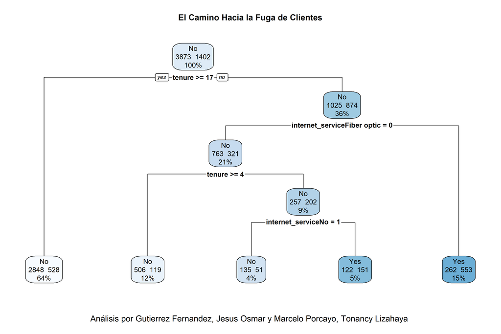

### **La Estrategia Inteligente: De la Predicción a la Acción Rentable**

En lugar de malgastar el presupuesto, ahora podemos enfocar el 100% de nuestros esfuerzos de retención en el segmento que estadísticamente más lo necesita, en el momento preciso.